# Projekt

## Wczytywanie potrzebnych bibliotek

```python
import pandas as pd
import numpy as np
import matplotlib.pyplot as plt
from bs4 import BeautifulSoup
import seaborn as sns
import requests
import matplotlib.patches as mpatches
import sklearn as sklearn
import sklearn.model_selection
import sklearn.linear_model
import sklearn.metrics
import statsmodels.api as sm
from sklearn.metrics.pairwise import pairwise_distances
from sklearn.manifold import MDS
from sklearn.preprocessing import MinMaxScaler
from sklearn.linear_model import LogisticRegression
from sklearn.tree import DecisionTreeClassifier
from sklearn.cluster import KMeans
```

## Cel projektu

Głównym zadaniem w projekcie jest wczytanie wszystkich krajów Świata wraz z kontynentem, na którym się znajduje, z internetu. Następnie wybraniu 3,4 kontynentów, na których bedzię się skupiało badanie. Po wybraniu kontynentów do badań, wczytano dane na temat krajów, takie jak:

- PKB na 1 mieszkanca,
- Gestosc zaludnienia[mieszkaniec/km^2],
- Długość życia(przewidywania od narodzin),
- Emisja CO2[tona/mieszkanca].

Po wybraniu odpowiednich danych zmergowano te dane tak, aby powstal jeden dateframe, który będzie klasyfikował na podstawie kolumny kontynent oraz zawierał powyższe zmienne.

Po przygotowaniu danych przeprowadzono serie analiz i zwizualizowano je.

## Wczytywanie i przygotowywanie danych

### Pobranie danych z internetu

Skorzystano ze strony: https://wisevoter.com/country-rankings/countries-by-continent/, aby zebrać dane na temat wszystkich państw świata. Ten dateframe posluzy jako podstawa do mergowania danych oraz poźniejszej klasyfikacji na podstawie kolumny kontynent.

```python
def clearing_content_cells(cells):
    """
        Funkcja która dostaje obecne komorki wyciagniete ze strony, czysci je ze znacznikow, a na koniec
        zwroci tablice wyczyszconych komorek.
    """
    """
        Tutaj pojawil sie problem, bo niektore dane na tej stronie byly w postaci <td><a>Moje dane</a></td>
        przez co nie moglam ich wyciagnac bezposrednio wiec od razu wyciagam napis z tagu 'a', a jesli nie
        ma tego tagu to wyciagam dane z 'td'.
    """
    cells_to_return = []

    for i,cell in enumerate(cells):

        # Sprawdzam czy jest tag
        if cell.find('a') is not None:
            # Jesli jest to wyciagam tekst i podmieniam wartości
            cell_temp = cell.get_text()
            cells_to_return.append(cell_temp)
            continue

        # Jesli nie ma tagu to wyciagam dane z 'td'
        cells_to_return.append(cell.contents[0])

    return cells_to_return


def content_cells(rows):
    # Lista na dane
    data_list = []

    # Iteruje po wierszach i wyszczegolniam poszczegolne komorki tabeli tak aby polaczyc je w jedna liste
    # Przy okazji filtruje dane, wyciagam tylko te kolumny, które chce w swoich danych, czyli panstwo oraz kontynent
    for row in rows:
        # Znajdowanie komórek
        cells = row.find_all('td')
        # Wybieram, które dane chce(panstwo i kontynent)


        # Daje do funckji obecne komorki, a ona je oczysci z tagow i zwroci
        cells = clearing_content_cells(cells)

        # Podmieniam tablice i zamieniam wszystkie napisy tak zeby mialy male litery
        cells = [element.lower() for element in cells]

        # Tworzenie listy z danymi
        data_list.append([cells[0],cells[1]])

    # Tworzenie gotowego dateframu
    df = pd.DataFrame(data_list)

    return df



def getting_data_internet(url):
    """
        Funckja, która dostaje url strony z której ma pobrać dane, a nastepnie zwraca gotowe dane w postaci dateframe z
        biblioteki pandas
    """

    # Scraper
    page = requests.get(url)
    soup = BeautifulSoup(page.text,'html.parser')

    # Tutaj znajduje tabele na stronie
    table = soup.find_all('table')[0]

    # Wczytuje tabele do zmiennej po wierszach
    rows = table.find_all('tr')[1:]
    # Przekazuje wiersze do funckji, która przejdzie po wierszach i na koniec zwroci mi gotowy zestaw danych w postaci dateframe
    df = content_cells(rows)

    # Ustawiam jeszcze nazwy kolumn
    df.columns = ['panstwo','kontynent']

    # Oczyszczenie dateframu z '\n'
    df = df.replace(r'\n',' ', regex=True)

    # Niektore z panstw maja 2 kontynenty w kolumnie kontynent dlatego tutaj skasuje drugi z kontynentow dla pozniejszej analizy
    df['kontynent'] = df['kontynent'].apply(lambda x: x.split(',')[0])
    # Sotowanie wartosci
    df = df.sort_values(by='panstwo')

    return df


dane_panstw = getting_data_internet("https://wisevoter.com/country-rankings/countries-by-continent/")

# Wyswietlanie danych
print(dane_panstw.head())
```

```
      panstwo    kontynent
57   afghanistan     asia
109      albania   europe
0        algeria   africa
110      andorra   europe
1         angola   africa
```

### Wczytanie danych z plików lokalnych

Do pobrania danych skorzystano ze strony https://www.gapminder.org/data/. Następnie wczytano je. Tematyka danych odzwierciedla zmienne opisane w celu projektu. Dane pochodzą z 2015 roku.

```python
def filtering_values(value):
    # Dane pochodzace ze strony sa skrocone literkami
    if type(value) is float or type(value) is int:
        return value
    elif 'k' in value:
        return float(value.replace('k','')) *1000
    elif 'M' in value:
        return float(value.replace('M','')) *1000000

    return float(value)

def filtering_dfs(lista):
    # Czego szukam w tych dateframach
    kolumny = ['country','2015']
    nazewnictwo = ['CO2','lifeExp','PKB','popDensity']
    lista_or = []

    for i,df in enumerate(lista_df):
        # Filtruje dane tak zeby zostal tylko rok 2015
        df = df.drop([col for col in df.columns if col not in kolumny ],axis=1)
        # Fitrowanie wartosci
        df['2015'] = df['2015'].apply(filtering_values)
        # Usuwanie pustych wartosci
        df = df.dropna(subset = ['2015'])
        # Nadanie poprawnej wartosci
        df.columns = ['panstwo',nazewnictwo[i]]
        lista_or.append(df)

    return lista_or



"""
    Najpierw wczytam wszystkie dane a nastepnie dodam je do lista_df i wykonam na nich potrzebne akcje
"""
co2 = pd.read_csv("Dane\\CO2.csv")
lifeExp = pd.read_csv("Dane\\lifeExp.csv")
pkb = pd.read_csv("Dane\\pkb.csv")
popDensity = pd.read_csv("Dane\\popDensity.csv",on_bad_lines='skip')

lista_df = [co2,lifeExp,pkb,popDensity]


"""
    Teraz wykonam potrzebne akcje na kazdym dateframie
"""

# Przekazuje to do funckji, która to wykona
lista_df = filtering_dfs(lista_df)



"""
    Teraz tworze jednego dateframy który bedzie przechowywal wszystkie informacje
"""

dane_panstw_tematy = lista_df[0]

for df in lista_df[1:]:
    dane_panstw_tematy = dane_panstw_tematy.merge(df,on = 'panstwo')

# Zamiana na male litery zeby nie bylo problemu z mergowaniem pozniej
dane_panstw_tematy['panstwo'] = dane_panstw_tematy['panstwo'].str.lower()

# Sortowanie po kolumnie panstwo alfabetycznie
dane_panstw_tematy = dane_panstw_tematy.sort_values(by='panstwo')


print(dane_panstw_tematy.head())
```

```
     panstwo      CO2   lifeExp    PKB    popDensity
0   afghanistan  0.262   61.9      592.0      52.0
2       albania  1.600   78.1     3950.0     105.0
47      algeria  3.800   75.4     4200.0      16.6
3       andorra  5.970   82.0    38900.0     153.0
1        angola  1.220   63.5     3100.0      22.6
```

## Łączenie danych i grupowanie

Finalny zbiór danych został sklasyfikowany przez kontynenty tak jak zostało to opisane wcześniej.

Ostatecznie do badania wybrano 4 kontynenty:

- Afryka
- Europa
- Azja
- Oceania

```python
# Mergowanie w 1 dateframe
dane = dane_panstw.merge(dane_panstw_tematy,on="panstwo")

kontynenty = ['asia','europe','africa','oceania']

# Wybieram tylko te rekordy ktore pochodza z wczesniej zapowiedzianych kontynetow
dane = dane[dane['kontynent'].isin(kontynenty)]
# Sortowanie
dane = dane.sort_values(by='kontynent')

# Teraz mozna pozbyc sie kolumny panstwo bo nie jest juz potrzebna
dane = dane.drop('panstwo',axis=1)

# Jest to ostateczna wersja  dateframu
print(dane.head())
print(dane.tail())
```

```
   kontynent   CO2   lifeExp    PKB   popDensity
91   africa   0.067   62.0     376.0    179.00
55   africa   2.690   66.3    7090.0      7.87
58   africa   0.579   64.2    1710.0    127.00
62   africa   0.215   58.5     756.0     47.30
63   africa   0.160   58.8     586.0     63.60
    kontynent    CO2   lifeExp    PKB    popDensity
153   oceania   1.200   72.6     4120.0     163.0
8     oceania  16.800   82.7    56700.0       3.1
81    oceania   0.562   59.9     1460.0     161.0
110   oceania   7.770   81.7    38600.0      17.3
158   oceania   0.991   67.4     3380.0     363.0
```

## Analiza danych

### Statystyki opisowe

```python
# Wyswietlanie danych
pd.set_option('display.max_rows', None)
pd.set_option('display.max_columns', None)
pd.set_option('display.width', 1000)
pd.set_option('display.colheader_justify', 'center')
pd.set_option('display.precision', 3)
print(dane.describe())
```

```
         CO2    lifeExp      PKB     popDensity
count  141.000  141.000     141.000    141.000
mean     4.712   71.117   13220.433    166.329
std      5.927    8.161   18938.776    265.924
min      0.039   48.500     289.000      1.900
25%      0.574   64.400    1460.000     38.700
50%      2.690   72.300    4120.000     82.600
75%      6.580   77.600   17400.000    163.000
max     41.300   84.300  105000.000   1740.000
```

### Liczność krajów dla danego kontynentu

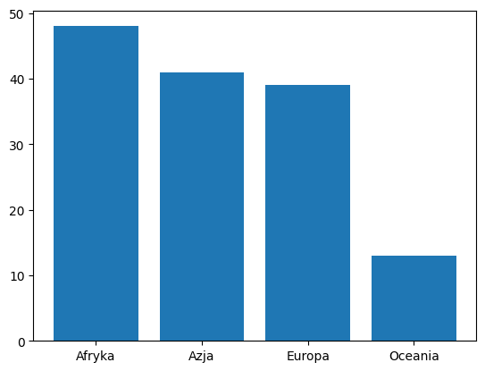

```python
opis = ["Afryka","Azja","Europa","Oceania"]

plt.bar(opis,dane.groupby("kontynent").size())
plt.show()
```

### Wykresy pudełkowe

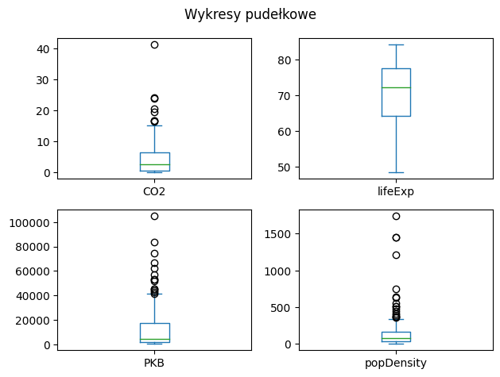

```python
dane.drop('kontynent',axis=1).plot(kind='box',subplots=True,layout=(2,2),sharex=False,sharey=False,title="Wykresy pudełkowe")

plt.tight_layout()
plt.show()
```

### Wykresy rozkładu

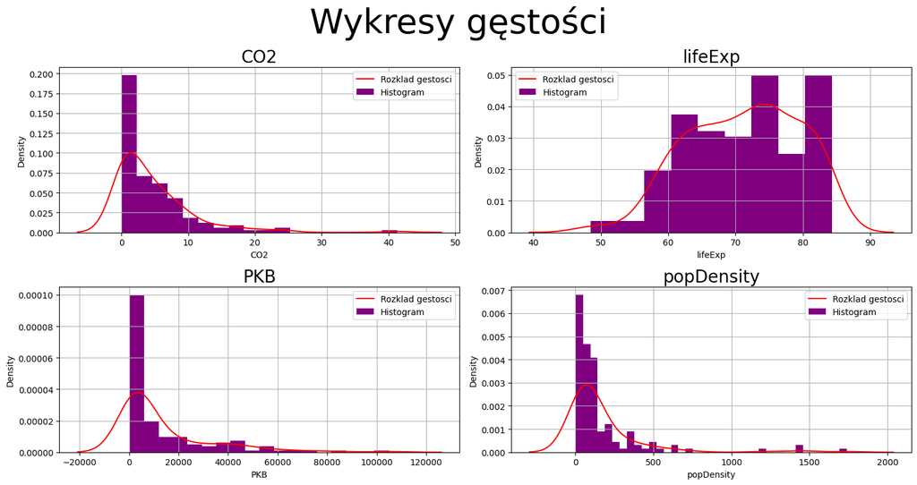

```python
fig, axs = plt.subplots(2,2, figsize=(15,8))

for i,kolumna in enumerate(dane.drop('kontynent',axis=1)):
    # Tworzenie histogramu
    ax = axs[i // 2,i % 2]
    dane[kolumna].hist(ax=ax,bins='auto',color='purple',density=True)

    # Tworzenie lini gestosci
    sns.kdeplot(dane[kolumna],ax=ax,color = 'red')

    ax.set_title(kolumna,fontsize=20)
    ax.legend(['Rozklad gestosci','Histogram'])


fig.suptitle("Wykresy gęstości",fontsize=40)
plt.tight_layout()
plt.show()
```

### Wykres rozrzutu

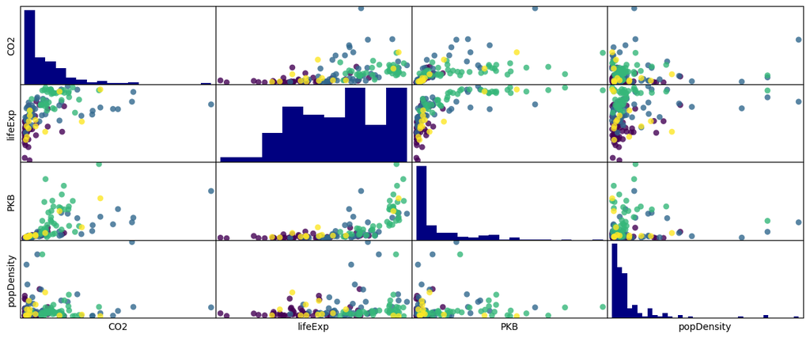

```python
# Przygotowanie do wykresu
dane_temp = pd.factorize(dane['kontynent'])[0]


scatter = pd.plotting.scatter_matrix(dane.drop('kontynent',axis=1),c=dane_temp,marker = 'o',s=40,
                                     hist_kwds={'bins':'auto','color':'navy'},figsize=(15,6),alpha=0.8)
for ax in scatter.ravel():
    ax.set_xticks([])
    ax.set_yticks([])
plt.show()
```

### Regresja liniowa

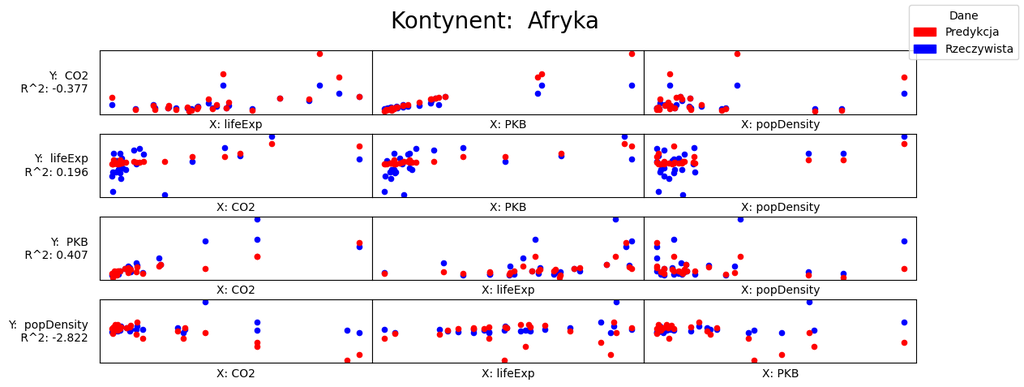

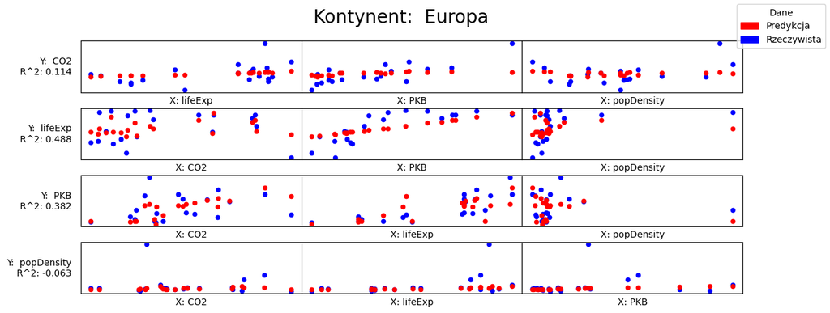

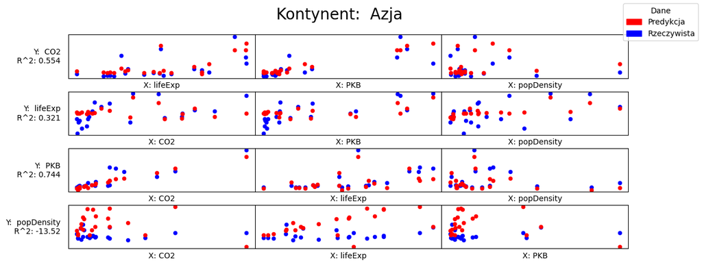

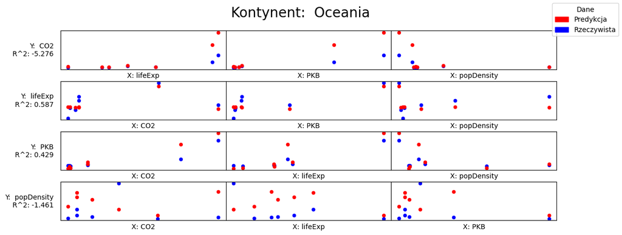

```python
def rysowanie_wykresu_subplot(Ypred,Xtest,Ytest,column_name,ax,r_2):
    # Funkcja dostaje wszystkie dane, które zebrala wczesniej w modelu regresji liniowej i na tej podstawie
    # rysuje wykres
    # Ustawiam napisy po lewo
    ax[0].set_ylabel("Y:  "+column_name+"\n R^2: "+str(round(r_2,3)),rotation=0,labelpad=10,va ='center',ha='right')

    # Teraz dla kazdej zmiennej obajsniajacej(X) rysuje wykres scatter
    for index,(name_xtest,xtest) in enumerate(Xtest.items()):
        ax[index].set_xticks([])
        ax[index].set_yticks([])
        ax[index].scatter(xtest,Ytest,color="blue",s=20)
        ax[index].scatter(xtest,Ypred,color="red",s=20)
        ax[index].set_xlabel("X: "+name_xtest)
        # ax[index].legend(title="Dane",loc = "lower left",fontsize = 8)


def tworzenie_wykresu(dataset,nazwa_kontynentu):

    # Tworze wykres, który będzie przetrzymywał wykresy
    figg,(ax1,ax2,ax3,ax4) = plt.subplots(4,3,figsize=(13,5),gridspec_kw={'hspace': 0.3,'wspace':0})

    wykresy = [ax1,ax2,ax3,ax4]
    wykres = 0
    # Teraz iteruje po kazdej kolumnie
    for column_name,column_data in dataset.items():
        # Podzial danych na zbior testowy i treningowy
        Y = column_data
        # X beda wszystkie kolumny oprocz tej obecnie wybranej(Y)
        X = dataset.drop(column_name,axis=1)
        X_train, X_test, Y_train, Y_test = sklearn.model_selection.train_test_split(X,Y,test_size=0.5)
        # Trenowanie modelu
        model = sklearn.linear_model.LinearRegression()
        model.fit(X_train,Y_train)
        y_pred = model.predict(X_test)

        # Sprwadzenie współczynnika determinacji
        r_2 = sklearn.metrics.r2_score(Y_test,y_pred)
        rysowanie_wykresu_subplot(y_pred,X_test,Y_test,column_name,wykresy[wykres],r_2)
        wykres +=1

    # Tworzenie legendy
    red_patch = mpatches.Patch(color='red', label='Predykcja')
    blue_patch = mpatches.Patch(color='blue', label='Rzeczywista')
    figg.suptitle("Kontynent:  "+str(nazwa_kontynentu),fontsize=20)
    figg.legend(handles=[red_patch,blue_patch],title="Dane",loc='upper right')
    plt.show()




# Przygotowanie danych i tworzenie wykresow
# Grupowanie danych ze wzgledu na nazwe kontynentu
np.random.seed(21)  # Ustawienie ziarna losowości dla numpy

africa = dane[dane['kontynent']=="africa"].drop('kontynent',axis=1)
tworzenie_wykresu(africa,"Afryka")
europa = dane[dane['kontynent']=="europe"].drop('kontynent',axis=1)
tworzenie_wykresu(europa,"Europa")
azja = dane[dane['kontynent']=="asia"].drop('kontynent',axis=1)
tworzenie_wykresu(azja,"Azja")
oceania = dane[dane['kontynent']=="oceania"].drop('kontynent',axis=1)
tworzenie_wykresu(oceania,"Oceania")
```

### Regresja krokowa

```python
# Zaczynamy od pełnego modelu
np.random.seed(21)  # Ustawienie ziarna losowości dla numpy

data_model = dane[dane['kontynent']=="africa"].drop('kontynent',axis=1)

# Podzial danych na zbior testowy i treningowy
Y = data_model['lifeExp']
# X beda wszystkie kolumny oprocz tej obecnie wybranej(Y)
X = data_model.drop('lifeExp',axis=1)

# Dodanie stalej
X = sm.add_constant(X)

# Tworzenie modelu
model = sm.OLS(Y,X)
results = model.fit()

print(results.summary())
```

```
                            OLS Regression Results
==============================================================================
Dep. Variable:                lifeExp   R-squared:                       0.312
Model:                            OLS   Adj. R-squared:                  0.265
Method:                 Least Squares   F-statistic:                     6.643
Date:                Thu, 15 Jun 2023   Prob (F-statistic):           0.000847
Time:                        00:02:32   Log-Likelihood:                -146.82
No. Observations:                  48   AIC:                             301.6
Df Residuals:                      44   BIC:                             309.1
Df Model:                           3
Covariance Type:            nonrobust
==============================================================================
                 coef    std err          t      P>|t|      [0.025      0.975]
------------------------------------------------------------------------------
const         60.2211      1.141     52.775      0.000      57.921      62.521
CO2            0.7378      0.675      1.094      0.280      -0.622       2.097
PKB            0.0006      0.000      1.239      0.222      -0.000       0.001
popDensity     0.0124      0.006      1.984      0.054      -0.000       0.025
==============================================================================
Omnibus:                        1.420   Durbin-Watson:                   1.812
Prob(Omnibus):                  0.492   Jarque-Bera (JB):                0.632
Skew:                          -0.038   Prob(JB):                        0.729
Kurtosis:                       3.557   Cond. No.                     5.85e+03
==============================================================================

Notes:
[1] Standard Errors assume that the covariance matrix of the errors is correctly specified.
[2] The condition number is large, 5.85e+03. This might indicate that there are
strong multicollinearity or other numerical problems.
```

```python
"""
    Stworzenie modelu
"""
def backward_regr(X,Y,results):
    """
        Funkcja która wykona regresje krokowa wsteczna
    """
    i = 1
    while len(X.columns) > 2:
        pvalues = results.pvalues[1:] # Pomijamy stala
        # Szukamy zmiennej w X ktora ma najwieksze pvalue, jako ze jest kandydatka do usuniecia
        feature_to_remove = np.argmax(pvalues)

        # Jezeli najwieksze pvalue dla jakiejkolwiek zmiennej wynosi mniej niz poziom istotnosci, to oznacza, że
        # zmienna jest statystycznie istotna i musi zostac w modelu wiec trzeba zatrzymac regresje wsteczna
        if pvalues[feature_to_remove] < 0.05:
            break

        # Usuwamy zmienna ktora miala najwieksze pvalue bo byla nieistotna
        X = X.drop(X.columns[feature_to_remove+1],axis =1 )
        # Dopasujemy nowy model
        model = sm.OLS(Y,X)
        results = model.fit()
        print("Krok " +str(i)+" regresji krokowej: ",str(X.columns.tolist()))


    return results

res = backward_regr(X,Y,results)
print("Koncowy Model regresji krokowej: \n\n")
print(res.summary())
```

```
Krok 1 regresji krokowej:  ['const', 'PKB', 'popDensity']
Krok 1 regresji krokowej:  ['const', 'PKB']
Koncowy Model regresji krokowej:


                            OLS Regression Results
==============================================================================
Dep. Variable:                lifeExp   R-squared:                       0.245
Model:                            OLS   Adj. R-squared:                  0.228
Method:                 Least Squares   F-statistic:                     14.90
Date:                Thu, 15 Jun 2023   Prob (F-statistic):           0.000353
Time:                        00:02:33   Log-Likelihood:                -149.05
No. Observations:                  48   AIC:                             302.1
Df Residuals:                      46   BIC:                             305.8
Df Model:                           1
Covariance Type:            nonrobust
==============================================================================
                 coef    std err          t      P>|t|      [0.025      0.975]
------------------------------------------------------------------------------
const         61.1953      1.049     58.363      0.000      59.085      63.306
PKB            0.0010      0.000      3.860      0.000       0.000       0.002
==============================================================================
Omnibus:                        0.489   Durbin-Watson:                   1.691
Prob(Omnibus):                  0.783   Jarque-Bera (JB):                0.115
Skew:                          -0.103   Prob(JB):                        0.944
Kurtosis:                       3.123   Cond. No.                     5.23e+03
==============================================================================

Notes:
[1] Standard Errors assume that the covariance matrix of the errors is correctly specified.
[2] The condition number is large, 5.23e+03. This might indicate that there are
strong multicollinearity or other numerical problems.
```

### Klasyfikacja

#### Multidimentional Scaling

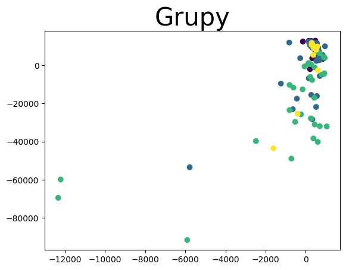

```python
# Przygotowanie do wykresu
dane_temp = pd.factorize(dane['kontynent'])[0]

similaritites = pairwise_distances(dane.drop('kontynent',axis=1),metric = 'euclidean')

mds = MDS(n_components=2,max_iter = 100,eps=1e-9,random_state=21,dissimilarity="precomputed",normalized_stress='auto')
pos = mds.fit(similaritites).embedding_

plt.scatter(pos[:,0],pos[:,1],c = dane_temp)
plt.title("Grupy",fontsize=30)
plt.show()
```

#### Regresja logiczna

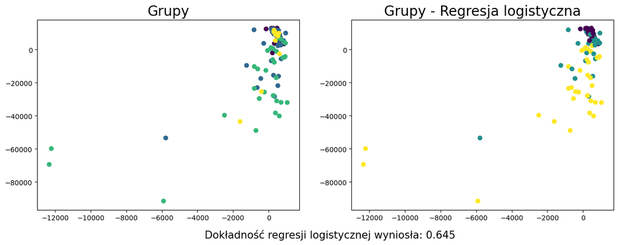

```python
# Przygotowania do wykresu
fig, ax = plt.subplots(ncols=2,nrows=1,figsize=(15,5))

ax[0].scatter(pos[:,0],pos[:,1],c = dane_temp)
ax[0].set_title("Grupy",fontsize=20)

#  Przygotowanie danych
X = dane.drop('kontynent',axis=1)
Y = dane_temp
scaler = MinMaxScaler()
X = scaler.fit_transform(X)

logreg = LogisticRegression()
logreg.fit(X,Y)

# Predykcja
y_pred = logreg.predict(X)

# Dokładność regresji logistycznej
accuracy = logreg.score(X,Y)


# Wykres
ax[1].scatter(pos[:,0],pos[:,1],c=y_pred)
ax[1].set_title("Grupy - Regresja logistyczna",fontsize=20)

fig.text(0.35,-0.005,"Dokładność regresji logistycznej wyniosła: "+str(round(accuracy,3)),fontsize=15)
plt.show()
```

#### Drzewo klasyfikacyjne

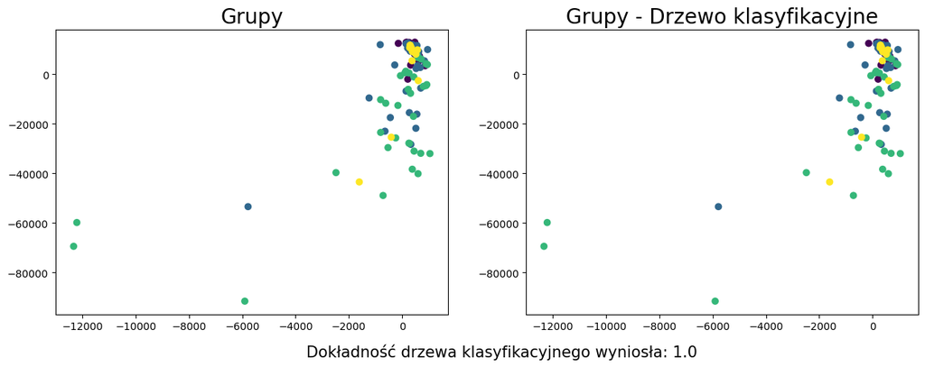

```python
# Przygotowania do wykresu
fig, ax = plt.subplots(ncols=2,nrows=1,figsize=(15,5))

ax[0].scatter(pos[:,0],pos[:,1],c = dane_temp)
ax[0].set_title("Grupy",fontsize=20)

# Algorytm drzewa
clf = DecisionTreeClassifier().fit(X,Y)
y_pred = clf.predict(X)
# Dokładność drzewa
accuracy = clf.score(X,Y)

# Wykres
ax[1].scatter(pos[:,0],pos[:,1],c=y_pred)
ax[1].set_title("Grupy - Drzewo klasyfikacyjne",fontsize=20)

fig.text(0.35,-0.005,"Dokładność drzewa klasyfikacyjnego wyniosła: "+str(round(accuracy,3)),fontsize=15)
plt.show()
```

### Klasteryzacja

#### K-Means

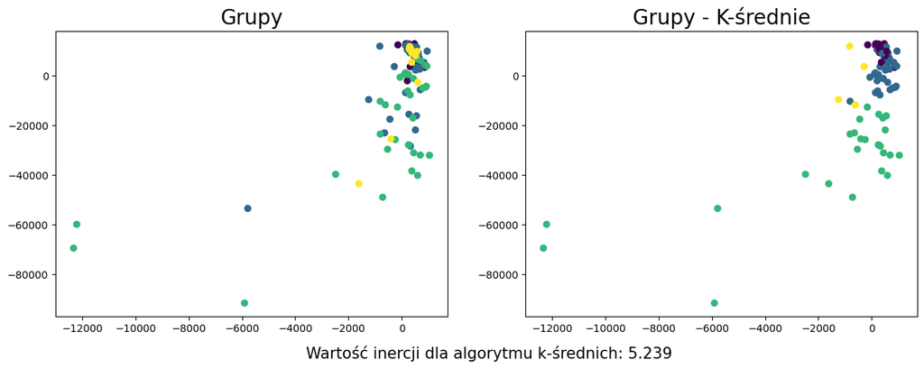

```python
# Przygotowania do wykresu
fig, ax = plt.subplots(ncols=2,nrows=1,figsize=(15,5))

ax[0].scatter(pos[:,0],pos[:,1],c = dane_temp)
ax[0].set_title("Grupy",fontsize=20)

# k-means method
clusterer = KMeans(n_clusters=4, random_state=21,n_init='auto')
cluster_labels = clusterer.fit_predict(X)

accuracy = clusterer.inertia_
# Wykres
ax[1].scatter(pos[:,0],pos[:,1],c=cluster_labels)
ax[1].set_title("Grupy - K-średnie",fontsize=20)

fig.text(0.35,-0.005,"Wartość inercji dla algorytmu k-średnich: "+str(round( accuracy,3)),fontsize=15)
plt.show()
```